# Bayesian Data Analysis - Rough Draft

Author

Sam Turner

Published

November 30, 2023

# Introduction and Motivations

To apply the methods discussed in *Statistical Rethinking* by Richard McElreath, Dr. Parson and I decided to replicate *Predicting Home Run Production in Major League Baseball Using a Bayesian Semiparametric Model* by Gilbert Fellingham and Jared Fisher. This article in particular has drawn our attention because of some unique and interesting modeling choices made by the authors. Both Dr. Parson and I believe that the initial investigation by Fellingham and Fisher (2017) is interesting, but there are some questionable modeling choices made by the authors throughout the paper. For example, there are few predictor variables and their associated priors are very weak. The paper does a good job with displaying plenty of visualizations for the reader, yet, under careful examination one is left with the impression that the authors have chosen to display a non-random assortment of players. This leaves careful readers wondering if the validity of their model is constant across all players, or if they have chosen a certain subset because these special players justify the use of their model. These reasons in tandem bring Fellingham and Fisher’s (2017) findings into question. Thus, Dr. Parson and I have embarked to investigate the same research question as them: can we use a multilevel Bayesian model to predict a player’s home run performance?

## Baseball Background

In Major League Baseball (MLB) the team on offense is allowed to send one player, at a time, up to home plate to “bat.” Any time a player is sent up to bat this constitutes a plate appearance (PA). Depending on the outcome of the PA it may or may not be considered an at-bat (AB). If the PA ends in the player being walked (BB [Base on Balls]) then it is not recorded as an AB because it is thought the player did not receive a fair chance at hitting the baseball. On the other hand, if the PA ends in the player getting a hit or getting out, then it is assumed that he had a fair chance at hitting the ball and the PA is recorded as an AB. This distinction to the average fan is mostly arbitrary. However, in a modeling context it is very important. When modeling a player’s ability to hit home runs (HR), as this paper is concerned with, the distinction is important because it is unfair to consider all the PA’s of a player because this set of outcomes includes outcomes where it is assumed that the player has not been given a fair chance to hit the ball. For similar reasons, considering the subset of outcomes where it is assumed that they player has been given a fair chance to hit the ball seems more appropriate, this subset is AB’s. Thus, this paper uses AB’s as the main predictor for home runs hit by a certain player. Fellingham and Fisher (2017) also agree with this reasoning and use AB’s, rather than PA’s, in their research.

An interesting quirk of baseball is that, like soccer, stadiums differ in dimensions. This is not universal; baseball fields and stadiums must have the same measurements for their infields. Yet, for the most part baseball stadiums are allowed to configure their outfields as they please. This becomes important because most HR’s are achieved by hitting the baseball over the outfield fence. Thus, fences closer to home plate generally lead to more HR’s for all hitters, ceteris paribus. The non-standardized nature of stadiums’ fences gives them a variety of unique shapes and ranging outfield sizes. For example, Fenway Park (1923-) is known to have the closest outfield wall with their “Green Monster” in left field being only 305 ft. from home plate. While the Polo Grounds (1891-1963) boasted one of the furthest walls from home plate at 483 ft. in center field. Stadiums also differ in location. Marlins Park (2012-2020) sits at 15 ft. above sea level while Coors Field (1995-) sits at 5183 ft. above sea level. As illustrated there are not only vastly different dimensions that baseball fields can take on but also different environments which affect a player’s ability to hit home runs. Thus, any model which attempts to model players’ ability to hit HR’s needs to consider ballpark factors.

## Literature Review

As mentioned, Fellingham and Fisher (2017) have both considered and published their thoughts on this research question. This research question concerns predicting player home run performance using Bayesian multilevel modeling. To do this, Fellingham and Fisher (2017) used data from the Lahman data set spanning 1871 to 2008 to estimate the parametric weights for their model. Over this time frame they only considered players who had played for at least 6 seasons and who, in each of those seasons, had at least 50 AB’s. They only considered seasons where the players were 18-years-old to 45-years-old.

To predict a player’s HR’s they used a binomial logistic model. This model predicts HR’s using the AB’s of a player for the $n$ trials and the underlying ability of a player to hit a HR, $\pi$ as their probability of success. Fellingham and Fisher (2017) estimate a player’s ability to hit home runs from his age in a season, decade born, season played, and home ball park. This leaves Fellingham and Fisher with the following model:

$$\begin{align}
h_{ij}|\pi_{ij}&\sim Binomial(ab_{ij},\pi_{ij})\\
\\
logit(\frac{\pi_{ij}}{1-\pi_{ij}})&=x_{ij}\beta_{i}+\theta_i+\delta_j
+\xi_p
\end{align}$$

Where $h_{ij}$ is the HR by a player $i$ in year $j$, $\pi_{ij}$ is the probability of a HR for player $i$ in year $j$, $ab$ is the number of AB’s for player $i$ in year $j$, $x_{ij}$ and $\beta_i$ are vectors of the associated weights of the orthogonal quartic polynomial for a player’s age on HR probabilities, $\theta_i$ is the effect of decade of birth, $\delta_j$ is the effect of season of play, and $\xi_p$ is the effect of the home ballpark.

What makes this model so strange are the priors that Fellingham and Fisher (2017) chose. Disregarding that there is no justification for these priors, Fellingham and Fisher (2017) set the following priors for these parameters:

$$\begin{align}
\theta_i&\sim Normal(\mu_d,\sigma^2_{d_i}), d\in \{1...14\}, i\in\{1,...,3735\}\\
\\
\mu_d&\sim Normal(-2.5,var=1), d_i\in\{1,...,14\}\\
\\
\sigma^2_{d_i}&\sim Gamma(3,3), d_i\in\{1,...14\} \\
\\
\delta_j&\sim Normal(-2.5, var=4),j\in \{1,...,138\}\\
\\
\xi_p&\sim Normal(-2.5, var=4), p\in \{1,...,222\}\\
\end{align}$$

Another questionable choice that Fellingham and Fisher (2017) make is that they estimated their model parameters using FORTRAN. Given the antiquity of FORTRAN, replication of Fellingham and Fisher (2017) is quite difficult. Not to mention that the 200,000 iterations makes the research so computationally expensive that it makes it nearly impossible for any other research team to replicate. This is disappointing because the scientific method relies on replication for the advancement of knowledge. Thus, our research seeks to make the algorithms used in this research more accessible because we chose to use R to interface with the modeling software Stan, which is written in the (more contemporary) C++ programming language.

Finally, we see that Fellingham and Fisher (2017) project the performance of a number of players from their considered 3,735. However, upon closer inspection these players do not seem to be randomly selected because the selected players were pretty renown during their prime. Nor, does Fellingham and Fisher (2017) make the assurance that these players are randomly selected. This should leave readers with unease because it is unclear how well their model fits most players, which seemed to be what the paper was trying to investigate. Although unlikely, it is conceivable that they only selected players which make their model appear the most reliable. Instead, our paper seeks to remedy this by considering a random assortment of players to examine the fit of our model.

# Model

Given all the previous problems with Fellingham and Fisher (2017) mentioned above, there is an argument to be made that a simple generalized linear model (GLM) could be used instead of their complicated Bayesian semiparametric model. While it is true that a GLM could be used to predict HR’s of a player it would not nearly be as accurate as a Bayesian model. Nor would it be able to as accurately capture the non-linearities present in the data. This is because the greatest strength of using the Bayesian technique is that it allows for multilevel models to be created. That is, Bayesian models allow for models to “learn” from other players and group certain players when there is not as much data available for them. In turn, this leads to better predictions about players where data is lacking. This “learning” is known as partial pooling, where the model identifies that parameters for each player (or year etc.) probably come from the same distribution but may not share the exact same estimates.

Exploring concretely how our model works will make it clearer than discussing it in the abstract. The current model that we have is the following:

$$\begin{align}
HR_{ni} &\sim Binomial(AB_{ni},\pi_{ni})\\
logit(\frac{\pi_{ni}}{1-\pi_{ni}}) &= \alpha_{n}+\beta_h+\eta_h+\delta_p+\xi_i
\end{align}$$

$$\begin{align}
\alpha_n&\sim Normal(\mu_0, \sigma_0)\\
\beta_h&\sim Normal(\mu_1, \sigma_1)\\
\eta_h&\sim Normal(\mu_2, \sigma_2)\\
\delta_p&\sim Normal(\mu_5, \sigma_5)\\
\xi_i&\sim Normal(\mu_6, \sigma_6)\\
\end{align}$$

$$\begin{align}
\mu_0 &\sim Normal(-3.5, 0.1)\\
\sigma_0&\sim Exponential(1)\\
\\
\mu_1&\sim Normal(0,0.01)\\
\sigma_1&\sim Exponential(10)\\
\\
\mu_2&\sim Normal(0,0.01)\\
\sigma_2&\sim Exponential(100)\\
\\
\mu_5&\sim Normal(0,0.01)\\
\sigma_5&\sim Exponential(10)\\
\\
\mu_6&\sim Normal(0,0.25)\\
\sigma_6&\sim Exponential(10)
\end{align}$$

We recognize that this depends on the hitter which is where the use of a multilevel model becomes useful. Instead of simply using the average probability as our intercept, which is what a dummy variable would do in a GLM, we are able to allow our model choose an intercept which agrees with the data but can adapt depending on the player. Thus, we let $\alpha$ be normally distributed with mean $\mu_0$ (where $\mu_0$ is normally distributed with mean -3.5 and standard deviation 0.1) and standard deviation $\sigma_0$ (where the parameter $\sigma_0$ itself is exponentially distributed).

$\beta_h$ the effect that a player being age $h$ has on HR probability. Similarly $\eta_h$ is the effect that a player’s age squared has on the probability of a HR in an AB. This squared term captures the non-linearity of HR as player’s age.

$\delta_p$ is the effect that a player’s home ballpark $p$ has on his underlying probability of hitting a home run.

$\xi_i$ represents the change in the underlying probability of player hitting a HR in the year $i$

# Results

[figure not shown]

# Tables

```
              AB    HR    PA    p park_index yearID  cAge
AB          1.00  0.65  1.00 0.21       0.00  -0.01 -0.11
HR          0.65  1.00  0.67 0.75       0.03   0.12 -0.04
PA          1.00  0.67  1.00 0.23       0.00  -0.02 -0.10
p           0.21  0.75  0.23 1.00       0.05   0.16  0.02
park_index  0.00  0.03  0.00 0.05       1.00   0.07  0.05
yearID     -0.01  0.12 -0.02 0.16       0.07   1.00  0.04
cAge       -0.11 -0.04 -0.10 0.02       0.05   0.04  1.00
```

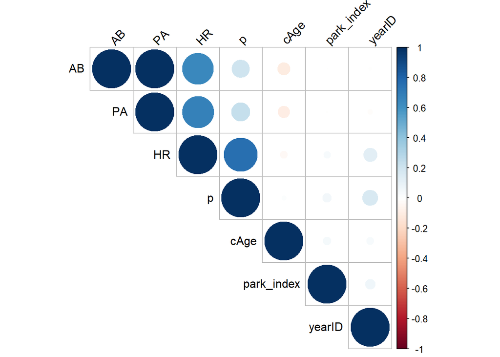

[output not shown]

# Figures

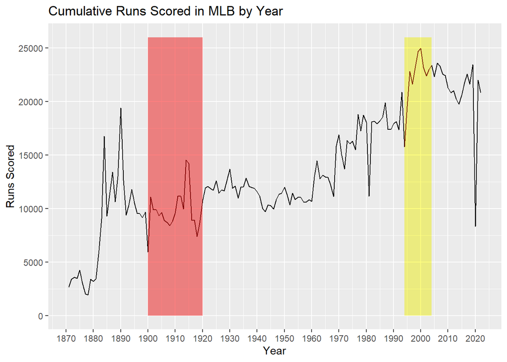

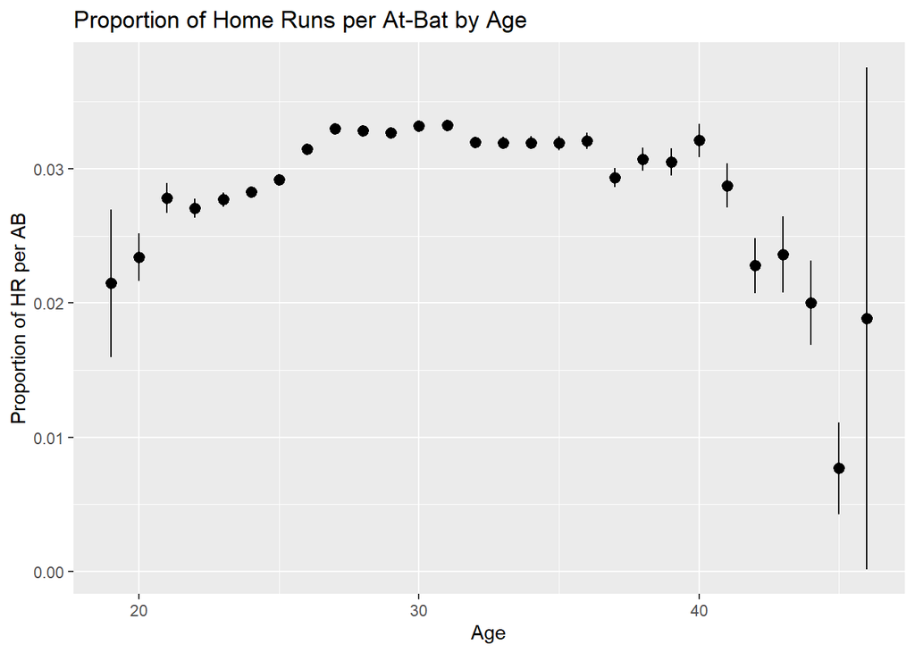

Figure 2: Proportion of Home Runs per At-Bat by Age

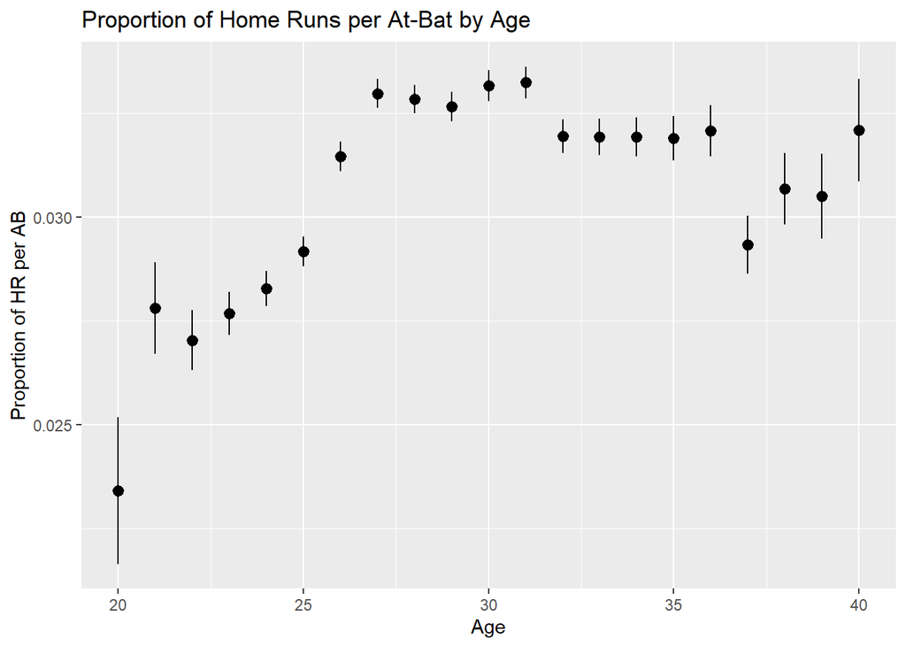

Figure 3: Proportion of Home Runs per At-Bat by Age

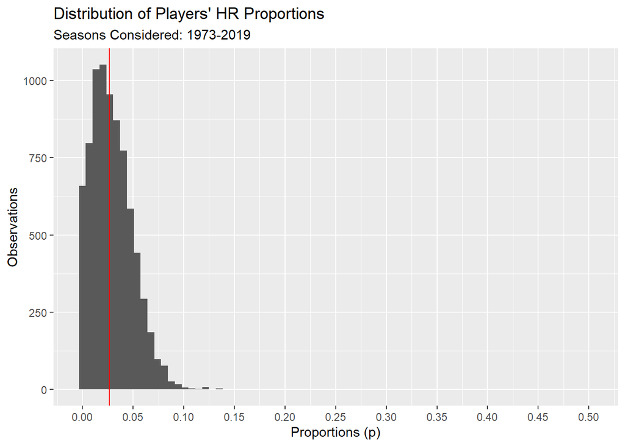

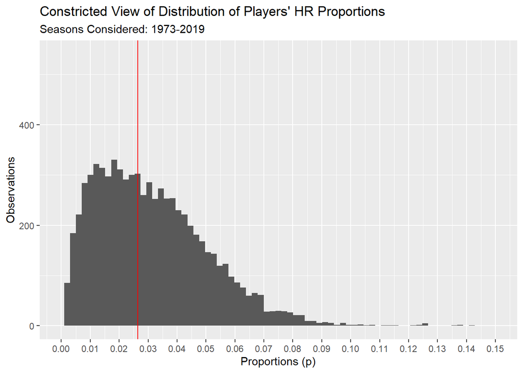